# Text Mining FOMC

christoffer.nordenlow@outlook.com

## Text mining FOMC Minutes 2021-01-27

FOMC Minutes are usually a hot topic on the financial markets. There are plenty of observeres trying to break down what they said, and what they didn´t say.This project aims to give colour on both the actual context but also (hopefully) the underlying meaning and sentiment. With the field of text mining, this projects breaks down the Minutes into multiple areas making plots out of words.

To be able to to compare Minutes by different length with each other, everything below is set in relation to total the number of words or paragraph in their respective Minutes. Please see *[github](https://github.com/cnordenlow/text-mining-fomc)* for methodology.

**Table of Contents**

- General sentiment
- Economic and financial market conditions
- Policy toolbox and topics
- In deeper breakdown of selected topics

### General sentiment

#### Net sentiment

*Net sentiment is calculated by extracting all positive and negative words, and then taking the difference between these divided by the total number of words.*

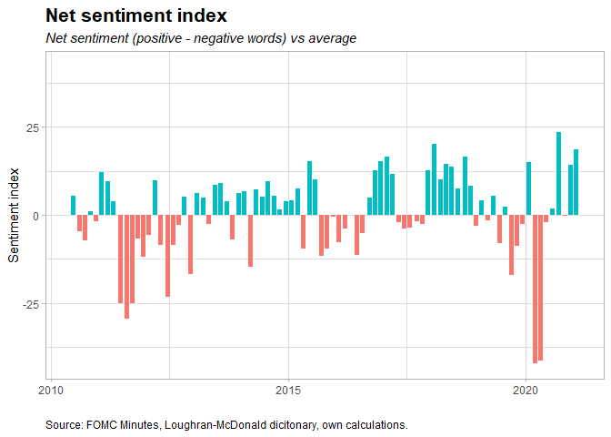

#### Intensifier index

*Intensifier-index shows the magnitude of the net sentiment by setting positive and negative words in combination with intensifier words (e.g. extremely, significant, sharply etc).*

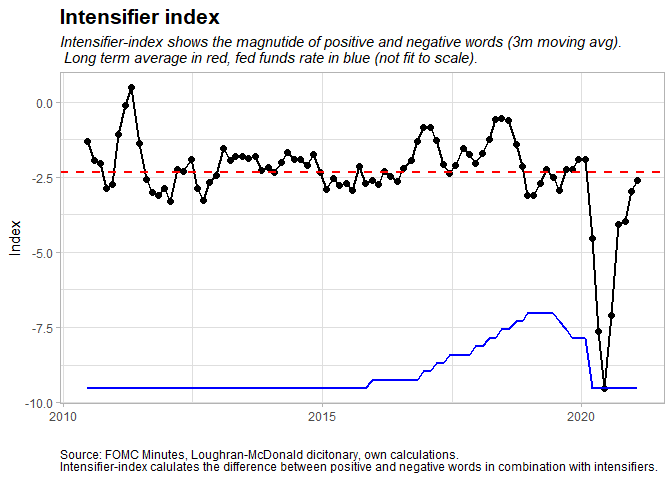

#### Strong-Weak-Moderate - Index

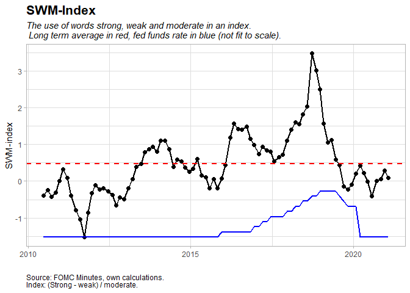

#### Selected sentiment indicators

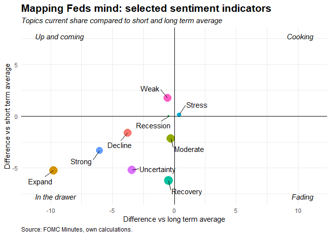

### Economic and financial market conditions

#### Economic topics

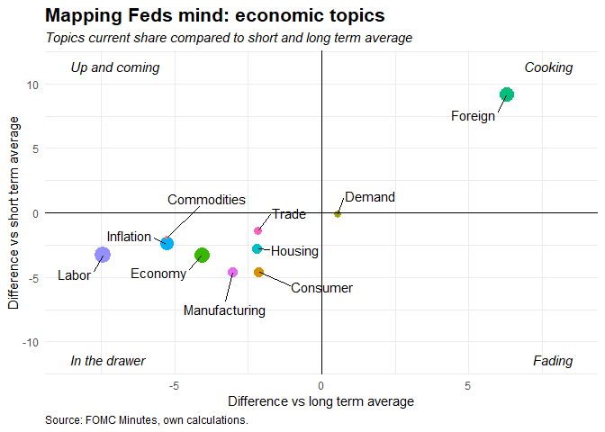

#### Sentiment analysis of economic topics

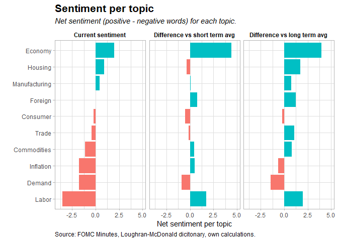

#### Financial markets

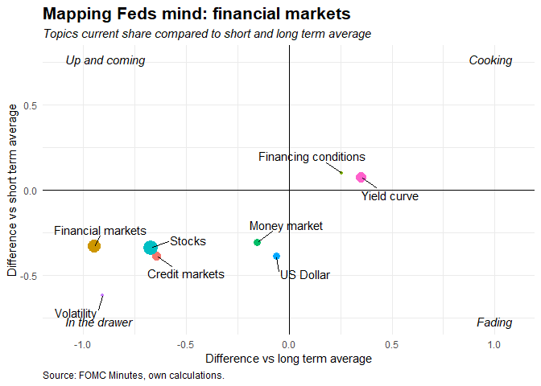

#### Sentiment analysis of financial markets

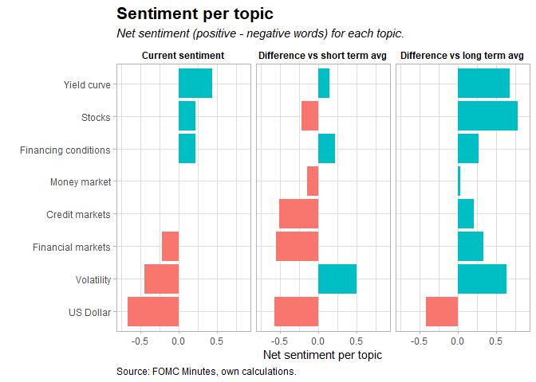

### Policy toolbox and topics

#### Policy toolbox

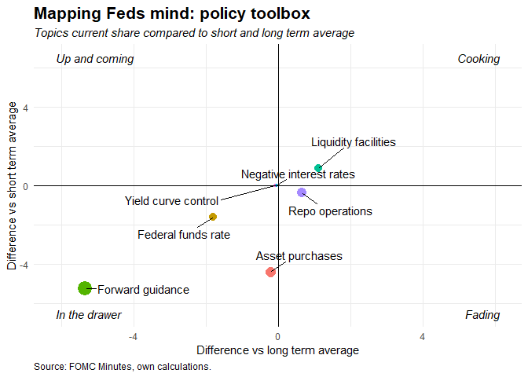

#### Policy key words

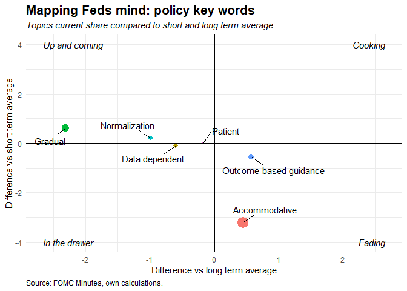

#### Key-words-O-Meters

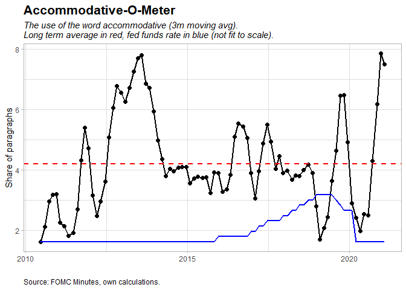

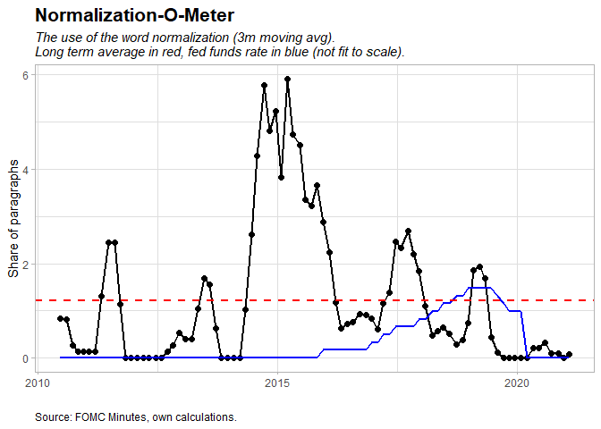

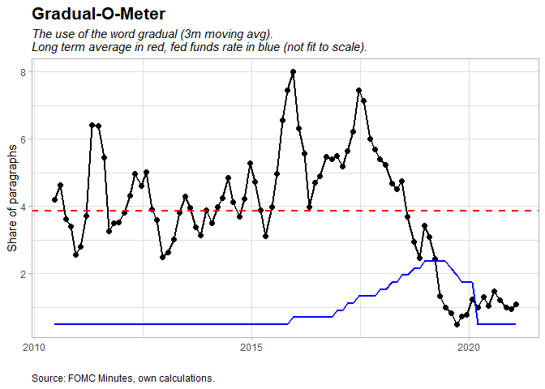

#### Policy action

*The graph below show the difference between sentences containing words like consensus, majority, all and those of words like a few, one or two. Above red dotted line suggest there are a more consensus view among participants then when below the dotted red line.*

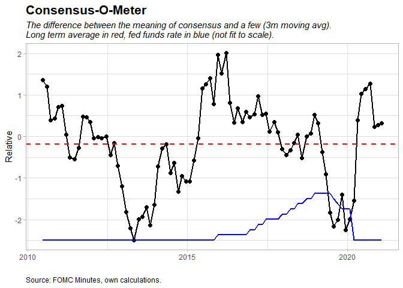

### In deeper breakdown

#### Inflation

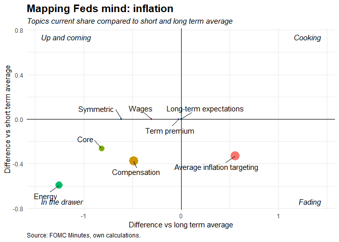

#### Labor market

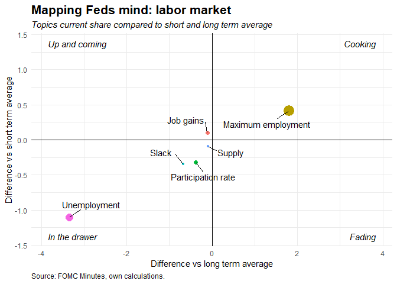

#### Asset purchases

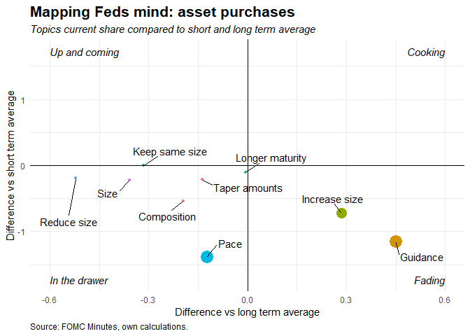